# Visualizing World’s Oldest Person data

André Garcia

### Introduction

The goal of this project is to do some basic exploration of a dataset developed by the Gerontology Research Group consisting of information about World’s Oldest Person (WOP) titleholders throughout time and to develop some visualizations based on it.

The data is available in https://grg.org/Adams/C.HTM

```r
# import relevant libraries

library(dplyr)
library(readxl)
library(stringr)
library(ggplot2)
library(knitr)
library(treemap)
```

### Importing the data

Since the dataset is small, it’s easy to just copy and paste it into an excel sheet and then import it into R.

Now let’s check if the data came out well.

```r
oldest <- read_excel("oldest.xlsx")
```

```r
kable(head(oldest))
```

| # | Birthplace | Name | Born | Died | Age | …7 | Race | Sex | Deathplace | When Oldest | …12 | Length of Reign | …14 | Reign Length | Age at Accession | …17 | Case added to GRG Tables |
| --- | --- | --- | --- | --- | --- | --- | --- | --- | --- | --- | --- | --- | --- | --- | --- | --- | --- |
| NA | NA | NA | NA | NA | Years | Days | NA | NA | NA | Years Range | Age Range | Years | Days | (In years) | Years | Days | (as world’s oldest person; only for retroactive case additions) |
| 1 | England (UK) | Betsy Baker | Aug. 20, 1842 | Oct. 24, 1955 | 113 | 65 | W | F | U.S. (NE) | ?-1955 | ?-113 | N.A. | N.A. | N.A. | N.A. | N.A. | N.A. |
| 2 | England (UK) | Jennie Howell | Feb. 11, 1845 | Dec. 16, 1956 | 111 | 309 | W | F | U.S. (CA) | 1955-1956 | 110-111 | 1 | 53 | 1.14 | 110 | 255 | Aug. 29, 2017 |
| 3 | Denmark | Anne Marie Carstenson | Jan. 24, 1849 | Mar. 30, 1958 | 109 | 65 | W | F | U.S. (NE) | 1956-1958 | 107-109 | 1 | 104 | 1.28 | 107 | 327 | N.A. (less than 110) |
| 4 | U.S. (IN) | Nancy Ryan | Sept. 5, 1849 | Oct. 17, 1958 | 109 | 42 | W | F | U.S. (IN) | 1958 | 108-109 | 0 | 201 | 0.55 | 108 | 206 | N.A. (less than 110) |
| 5 | Netherlands | Christina Karnebeek-Backs | Oct. 2, 1849 | Oct. 7, 1959 | 110 | 5 | W | F | Netherlands | 1958-1959 | 109-110 | 0 | 355 | 0.97 | 109 | 15 | original 1999 list |

```r
# kable function makes output look nicer
```

```r
colnames(oldest)
```

```
##  [1] "#"                        "Birthplace"
##  [3] "Name"                     "Born"
##  [5] "Died"                     "Age"
##  [7] "...7"                     "Race"
##  [9] "Sex"                      "Deathplace"
## [11] "When Oldest"              "...12"
## [13] "Length of Reign"          "...14"
## [15] "Reign Length"             "Age at Accession"
## [17] "...17"                    "Case added to GRG Tables"
```

Because of the weird design of the original table, some column names have two layers. So when we imported the data an extra row was created with the second layer of some column names. Let’s correct that by making column names clearer and then delete this first row.

```r
new_columns = c('#', 'Birthplace', 'Name', 'Born', 'Died', 'Age_Years', 'Age_Days', 'Race', 'Sex', 'Deathplace', 'Oldest_YrRange', 'Oldest_AgeRange', 'Length_Years', 'Length_Days', 'Reign_Years', 'AccessionAge_Years', 'AccessionAge_Days', 'AddedToTable')
colnames(oldest) <- new_columns
oldest <- oldest[-1,]
```

```r
kable(head(oldest))
```

| # | Birthplace | Name | Born | Died | Age_Years | Age_Days | Race | Sex | Deathplace | Oldest_YrRange | Oldest_AgeRange | Length_Years | Length_Days | Reign_Years | AccessionAge_Years | AccessionAge_Days | AddedToTable |
| --- | --- | --- | --- | --- | --- | --- | --- | --- | --- | --- | --- | --- | --- | --- | --- | --- | --- |
| 1 | England (UK) | Betsy Baker | Aug. 20, 1842 | Oct. 24, 1955 | 113 | 65 | W | F | U.S. (NE) | ?-1955 | ?-113 | N.A. | N.A. | N.A. | N.A. | N.A. | N.A. |
| 2 | England (UK) | Jennie Howell | Feb. 11, 1845 | Dec. 16, 1956 | 111 | 309 | W | F | U.S. (CA) | 1955-1956 | 110-111 | 1 | 53 | 1.14 | 110 | 255 | Aug. 29, 2017 |
| 3 | Denmark | Anne Marie Carstenson | Jan. 24, 1849 | Mar. 30, 1958 | 109 | 65 | W | F | U.S. (NE) | 1956-1958 | 107-109 | 1 | 104 | 1.28 | 107 | 327 | N.A. (less than 110) |
| 4 | U.S. (IN) | Nancy Ryan | Sept. 5, 1849 | Oct. 17, 1958 | 109 | 42 | W | F | U.S. (IN) | 1958 | 108-109 | 0 | 201 | 0.55 | 108 | 206 | N.A. (less than 110) |
| 5 | Netherlands | Christina Karnebeek-Backs | Oct. 2, 1849 | Oct. 7, 1959 | 110 | 5 | W | F | Netherlands | 1958-1959 | 109-110 | 0 | 355 | 0.97 | 109 | 15 | original 1999 list |
| 6 | Norway | Marie Olsen | May 1, 1850 | Nov. 24, 1959 | 109 | 207 | W | F | Norway | 1959 | 109 | 0 | 48 | 0.13 | 109 | 159 | N.A. (less than 110) |

Looks better now!

### Data visualization

We could start by making some visualizations using Birthplace data. However, the column data is a bit confusing, since sometimes there is information in parentheses about states inside a country or brackets related to a footnote. Let’s get rid of those.

```r
oldest$Birthplace
```

```
##  [1] "England (UK)"                      "England (UK)"
##  [3] "Denmark"                           "U.S. (IN)"
##  [5] "Netherlands"                       "Norway"
##  [7] "U.S. (MI)"                         "England (UK)"
##  [9] "U.S. (TX)"                         "England (UK)"
## [11] "England (UK)"                      "South Africa"
## [13] "Czechoslovakia"                    "England (UK)"
## [15] "Spain"                             "England (UK)"
## [17] "N. Ireland (UK)"                   "Japan"
## [19] "Japan"                             "U.S. (MO)"
## [21] "France"                            "U.S. (IL)"
## [23] "France"                            "U.S. (NH)"
## [25] "U.S. (MO)"                         "U.S. (VA)"
## [27] "Germany (now Poland) [5]"          "U.S. (CA)"
## [29] "England (UK)"                      "U.S. (PA)"
```

[output cut: 18 more lines]

```r
pattern = '\\([\\w\\s]+\\)'
pattern2 = '\\[\\d+\\]'
Birthplace <- oldest$Birthplace %>%
  str_replace(pattern2, '') %>%
  str_replace(pattern, '') %>%
  str_trim()
Birthplace
```

```
##  [1] "England"             "England"             "Denmark"
##  [4] "U.S."                "Netherlands"         "Norway"
##  [7] "U.S."                "England"             "U.S."
## [10] "England"             "England"             "South Africa"
## [13] "Czechoslovakia"      "England"             "Spain"
## [16] "England"             "N. Ireland"          "Japan"
## [19] "Japan"               "U.S."                "France"
## [22] "U.S."                "France"              "U.S."
## [25] "U.S."                "U.S."                "Germany"
## [28] "U.S."                "England"             "U.S."
## [31] "France"              "Canada"              "U.S."
## [34] "England"             "France"              "U.S."
## [37] "England"             "Cape Verde"          "U.S."
## [40] "Japan"               "Japan"               "Puerto Rico"
## [43] "Ecuador"             "U.S."                "Puerto Rico"
## [46] "U.S."                "Japan"               "U.S."
## [49] "Portugal"            "U.S."                "Japan"
## [52] "France"              "Brazil"              "U.S."
## [55] "Italy"               "Japan"               "Japan"
## [58] "U.S."                "U.S."                "U.S."
## [61] "Italy"               "British West Indies" "Japan"
## [64] "Japan"               "Japan"
```

```r
oldest$Birthplace <- Birthplace
```

Let’s see which countries had more people that held the title of World’s Oldest Person.

```r
birthplace_df <- as.data.frame(table(Birthplace))
birthplace_df <- birthplace_df[order(-birthplace_df$Freq),]
row.names(birthplace_df) <- NULL
birthplace_df
```

```
##             Birthplace Freq
## 1                 U.S.   21
## 2                Japan   11
## 3              England   10
## 4               France    5
## 5                Italy    2
## 6          Puerto Rico    2
## 7               Brazil    1
## 8  British West Indies    1
## 9               Canada    1
## 10          Cape Verde    1
## 11      Czechoslovakia    1
## 12             Denmark    1
## 13             Ecuador    1
## 14             Germany    1
## 15          N. Ireland    1
## 16         Netherlands    1
## 17              Norway    1
## 18            Portugal    1
## 19        South Africa    1
## 20               Spain    1
```

The country with more WOP title holders, according to our dataset, is the US (21 people), followed by Japan (11) and England (10). France comes in fourth (5), followed by Italy and Puerto Rico (2 each). After that, several countries have 1 person. We can better visualize the data by plotting it.

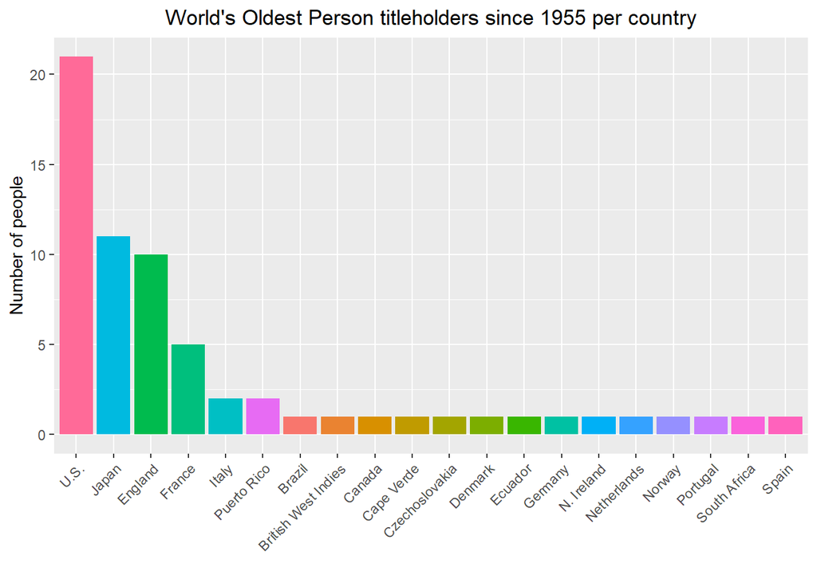

```r
ggplot(birthplace_df,
       aes(reorder(Birthplace, -Freq), Freq, fill=Birthplace)) +
       geom_col() +
       labs(
         title = "World's Oldest Person titleholders since 1955 per country",
         x = '',
         y = "Number of people") +
       theme(plot.title = element_text(hjust = 0.5)) +
       theme(axis.text.x = element_text(angle = 45, hjust = 1)) +
       theme(legend.position = 'none')
```

It’s time to check the male/female ratio in the dataset.

```r
table(oldest$Sex)/length(oldest$Sex)
```

```
##
##          F          M
## 0.90769231 0.09230769
```

Approximately 90.77% of WOP titleholders are women, while 9.23% are men.

We can build a pie chart to visualize this.

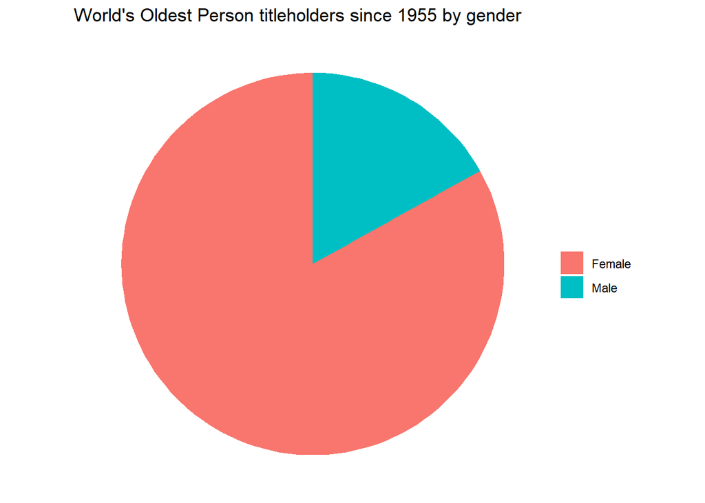

```r
ggplot(oldest, aes(x="", y=Sex, fill=Sex)) +
  geom_bar(stat="identity", width=1) +
  coord_polar("y", start=0) +
  labs(
       title = "World's Oldest Person titleholders since 1955 by gender",
       x = '',
       y = '') +
  theme(plot.title = element_text(hjust = 0.5)) +
  theme_void() +
  scale_fill_discrete(name="", labels=c("Female", "Male"))
```

Now let’s explore a bit some numerical columns.

```r
summary(oldest)
```

```
##        #       Birthplace            Name               Born
##  Min.   : 1   Length:65          Length:65          Length:65
##  1st Qu.:17   Class :character   Class :character   Class :character
##  Median :33   Mode  :character   Mode  :character   Mode  :character
##  Mean   :33
##  3rd Qu.:49
##  Max.   :65
##      Died            Age_Years           Age_Days             Race
##  Length:65          Length:65          Length:65          Length:65
##  Class :character   Class :character   Class :character   Class :character
##  Mode  :character   Mode  :character   Mode  :character   Mode  :character
##
##
##
##      Sex             Deathplace        Oldest_YrRange     Oldest_AgeRange
##  Length:65          Length:65          Length:65          Length:65
##  Class :character   Class :character   Class :character   Class :character
##  Mode  :character   Mode  :character   Mode  :character   Mode  :character
##
##
##
##  Length_Years       Length_Days        Reign_Years        AccessionAge_Years
##  Length:65          Length:65          Length:65          Length:65
##  Class :character   Class :character   Class :character   Class :character
##  Mode  :character   Mode  :character   Mode  :character   Mode  :character
##
##
##
##  AccessionAge_Days  AddedToTable
##  Length:65          Length:65
##  Class :character   Class :character
##  Mode  :character   Mode  :character
##
##
##
```

We can see that the datatypes of the columns are wrong (‘character’), so we need to do some data cleaning before we can build visualizations with them. One of the several issues that may have pushed R to use the ‘character’ class for the columns is that on the last row there are many numbers with asterisks on them. That’s because that row refers to Kane Tanaka, which was still alive when the table was made (and according to Wikipedia is still alive today!). We’ve decided to focus on historical data, so we are going to discard that last row for our numerical calculations. We’ll do the same with the first row, which is full of NA values.

```r
oldest_clean <- oldest[c(-1, -65),]
```

We’ll start with the ‘ReignYears’ column which represents for how long (in years) each person held the WOP title, that is, the length of their “Reign”.

```r
oldest_clean$Reign_Years
```

```
##  [1] "     1.14" "     1.28" "     0.55" "     0.97" "     0.13" "     5.10"
##  [7] "     0.18" "     0.42" "     0.43" "     2.19" "    0.24"  "     0.88"
## [13] "     0.69" "     3.13" "     0.47" "    0.20"  "     1.58" "     1.46"
## [19] "     1.04" "     0.39" "     2.75" "     0.12" "     1.68" "     0.92"
## [25] "    1.35"  "     1.68" "     0.28" "     0.90" "     0.04" "     9.56"
## [31] "     0.70" "     1.71" "     0.84" "     0.59" "     0.78" "     0.19"
## [37] "     0.23" "     0.36" "     0.75" "     0.13" "     0.54" "     2.25"
## [43] "     0.29" "     0.12" "     0.01" "     0.54" "     1.29" "     0.10"
## [49] "     0.69" "    0.64"  "     0.51" "     0.63" "     1.45" "     0.04"
## [55] "     0.48" "     1.80" "     0.01" "     0.20" "     0.90" "     0.92"
## [61] "     0.42" "    0.60"  "     0.25"
```

```r
oldest_clean$Reign_Years <- as.numeric(str_trim(oldest_clean$Reign_Years))
oldest_clean$Reign_Years
```

```
##  [1] 1.14 1.28 0.55 0.97 0.13 5.10 0.18 0.42 0.43 2.19 0.24 0.88 0.69 3.13 0.47
## [16] 0.20 1.58 1.46 1.04 0.39 2.75 0.12 1.68 0.92 1.35 1.68 0.28 0.90 0.04 9.56
## [31] 0.70 1.71 0.84 0.59 0.78 0.19 0.23 0.36 0.75 0.13 0.54 2.25 0.29 0.12 0.01
## [46] 0.54 1.29 0.10 0.69 0.64 0.51 0.63 1.45 0.04 0.48 1.80 0.01 0.20 0.90 0.92
## [61] 0.42 0.60 0.25
```

If we want to plot this variable against the ‘Oldest_YrRange’ column, which represents the period when each specific person held the title, we need to do something about that column as well. To simplify things, we are going to keep only the year at the end of the reign (year of death). We are interested in detecting main trends, so that won’t have a meaningful impact on our analysis.

```r
oldest_clean$Oldest_YrRange
```

```
##  [1] "1955-1956" "1956-1958" "1958"      "1958-1959" "1959"      "1959-1964"
##  [7] "1964-1965" "1965"      "1965-1966" "1966-1968" "1968"      "1968-1969"
## [13] "1969-1970" "1970-1973" "1973"      "1973"      "1973-1975" "1975-1976"
## [19] "1976-1977" "1977-1978" "1978-1981" "1981"      "1981-1982" "1982-1983"
## [25] "1983-1985" "1985-1986" "1986-1987" "1987"      "1987-1988" "1988-1997"
## [31] "1997-1998" "1998-1999" "1999-2000" "2000-2001" "2001-2002" "2002"
## [37] "2002"      "2002"      "2002-2003" "2003"      "2003-2004" "2004-2006"
## [43] "2006"      "2006-2007" "2007"      "2007"      "2007-2008" "2008-2009"
## [49] "2009"      "2009-2010" "2010"      "2010-2011" "2011-2012" "2012"
## [55] "2012-2013" "2013-2015" "2015"      "2015"      "2015-2016" "2016-2017"
## [61] "2017"      "2017-2018" "2018"
```

```r
oldest_clean$Death_Year <- oldest_clean$Oldest_YrRange %>%
  str_sub(-4, -1) %>%
  as.numeric()
oldest_clean$Death_Year
```

```
##  [1] 1956 1958 1958 1959 1959 1964 1965 1965 1966 1968 1968 1969 1970 1973 1973
## [16] 1973 1975 1976 1977 1978 1981 1981 1982 1983 1985 1986 1987 1987 1988 1997
## [31] 1998 1999 2000 2001 2002 2002 2002 2002 2003 2003 2004 2006 2006 2007 2007
## [46] 2007 2008 2009 2009 2010 2010 2011 2012 2012 2013 2015 2015 2015 2016 2017
## [61] 2017 2018 2018
```

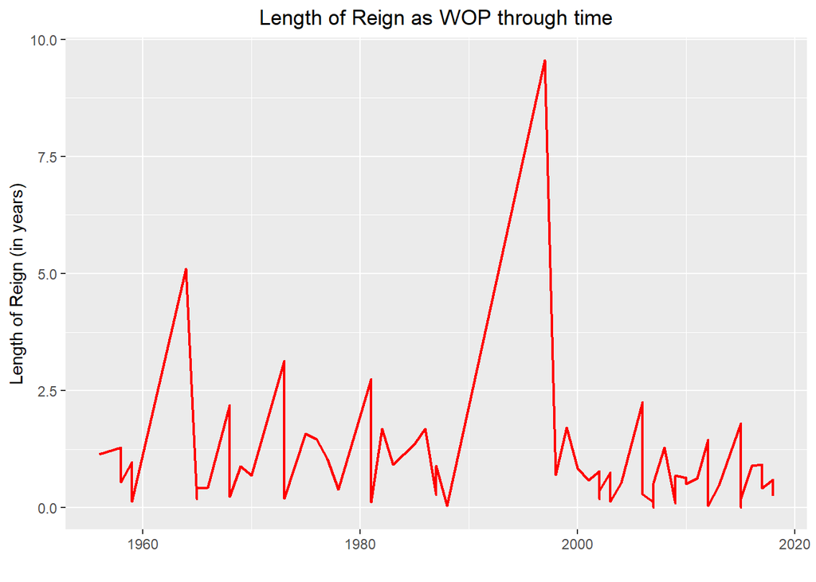

```r
ggplot(oldest_clean,
       aes(Death_Year, Reign_Years)) +
       geom_line(color="red", size=0.8) +
       labs(
         title = "Length of Reign as WOP through time",
         x = '',
         y = "Length of Reign (in years)") +
       theme(plot.title = element_text(hjust = 0.5))
```

We can see that ‘length of reign’ mostly oscillates between less than one year and around 2.5 years, with a couple of peaks in the mid 60s (around 5 years) and late 90s (around 9.5 years).

The exact numbers for the lengths can be seen below, in descending order.

```r
sort(oldest_clean$Reign_Years, decreasing = TRUE)
```

```
##  [1] 9.56 5.10 3.13 2.75 2.25 2.19 1.80 1.71 1.68 1.68 1.58 1.46 1.45 1.35 1.29
## [16] 1.28 1.14 1.04 0.97 0.92 0.92 0.90 0.90 0.88 0.84 0.78 0.75 0.70 0.69 0.69
## [31] 0.64 0.63 0.60 0.59 0.55 0.54 0.54 0.51 0.48 0.47 0.43 0.42 0.42 0.39 0.36
## [46] 0.29 0.28 0.25 0.24 0.23 0.20 0.20 0.19 0.18 0.13 0.13 0.12 0.12 0.10 0.04
## [61] 0.04 0.01 0.01
```

Now it’s time to visualize the average reign length by country.

```r
mean_reign <- oldest_clean %>%
  group_by(Birthplace) %>%
  summarize(mean_reign_yrs= mean(Reign_Years))
mean_reign <- mean_reign[order(-mean_reign$mean_reign_yrs),]
mean_reign
```

```
## # A tibble: 20 x 2
##    Birthplace          mean_reign_yrs
##    <chr>                        <dbl>
##  1 Spain                        3.13
##  2 Ecuador                      2.25
##  3 France                       2.23
##  4 Germany                      1.68
##  5 Denmark                      1.28
##  6 U.S.                         1.04
##  7 Netherlands                  0.97
##  8 Czechoslovakia               0.88
##  9 Japan                        0.823
## 10 England                      0.781
## 11 Canada                       0.7
## 12 Brazil                       0.63
## 13 Italy                        0.48
## 14 British West Indies          0.42
## 15 Puerto Rico                  0.33
## 16 South Africa                 0.24
## 17 Cape Verde                   0.23
## 18 N. Ireland                   0.2
## 19 Norway                       0.13
## 20 Portugal                     0.1
```

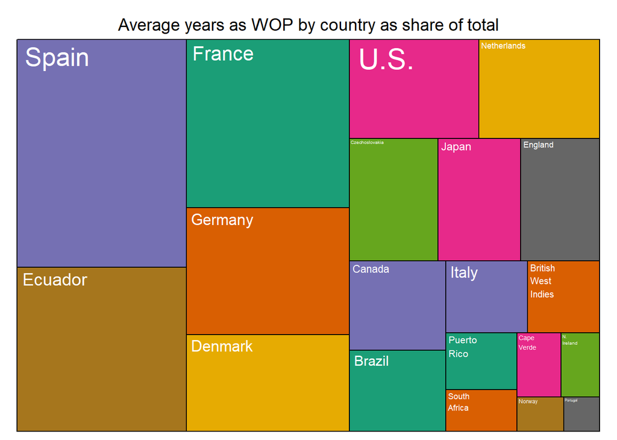

```r
treemap(mean_reign,
        index="Birthplace",
        vSize="mean_reign_yrs",
        type="index",
        title="Average years as WOP by country as share of total",
        palette="Dark2",
        border.col=c("black"),
        border.lwds=1,
        fontsize.labels=0.5,
        fontcolor.labels="white",
        fontface.labels=1,
        bg.labels="transparent",
        align.labels=c("left", "top"),
        overlap.labels=0.5,
        inflate.labels=T)
```

It’s interesting to see that Spain and Ecuador have a prominent position in the plot above. However, they both have only one person each in the dataset, so we can’t really draw any conclusions from this, since the result could be attributed to chance. Countries with more people in the dataset, like the US, tend to have more variation, which pulls the average down, away from the atypical higher values.

To wrap it up, let’s check how the oldest age reached by the WOP changed over time. The dataset has this data divided between 2 columns: one with full years lived and another with “extra” days. To make our analysis more precise, let’s create a third column that integrates the information from those 2. We can divide the days column by 365.25 (average duration of year) and add the result to the years column.

```r
oldest_clean$Age_Days <- as.numeric(oldest_clean$Age_Days)
oldest_clean$Age_Years <- as.numeric(oldest_clean$Age_Years)
oldest_clean$Age_Total <- oldest_clean$Age_Days/365.25 + oldest_clean$Age_Years
kable(oldest_clean[,c('Age_Years', 'Age_Days', 'Age_Total')])
```

| Age_Years | Age_Days | Age_Total |
| --- | --- | --- |
| 111 | 309 | 111.8460 |
| 109 | 65 | 109.1780 |
| 109 | 42 | 109.1150 |
| 110 | 5 | 110.0137 |
| 109 | 207 | 109.5667 |
| 113 | 206 | 113.5640 |
| 109 | 298 | 109.8159 |
| 110 | 30 | 110.0821 |
| 110 | 3 | 110.0082 |
| 111 | 280 | 111.7666 |
| 111 | 151 | 111.4134 |
| 111 | 194 | 111.5311 |
| 111 | 339 | 111.9281 |
| 112 | 228 | 112.6242 |
| 112 | 39 | 112.1068 |
| 110 | 235 | 110.6434 |
| 112 | 65 | 112.1780 |
| 113 | 103 | 113.2820 |
| 111 | 155 | 111.4244 |
| 111 | 266 | 111.7283 |
| 113 | 283 | 113.7748 |
| 112 | 65 | 112.1780 |
| 113 | 81 | 113.2218 |
| 113 | 154 | 113.4216 |
| 114 | 222 | 114.6078 |
| 115 | 79 | 115.2163 |
| 113 | 248 | 113.6790 |
| 114 | 208 | 114.5695 |
| 114 | 93 | 114.2546 |
| 122 | 164 | 122.4490 |
| 117 | 230 | 117.6297 |
| 119 | 97 | 119.2656 |
| 114 | 360 | 114.9856 |
| 115 | 42 | 115.1150 |
| 115 | 56 | 115.1533 |
| 114 | 194 | 114.5311 |
| 114 | 183 | 114.5010 |
| 113 | 343 | 113.9391 |
| 114 | 189 | 114.5175 |
| 114 | 182 | 114.4983 |
| 114 | 272 | 114.7447 |
| 116 | 347 | 116.9500 |
| 116 | 118 | 116.3231 |
| 115 | 156 | 115.4271 |
| 114 | 67 | 114.1834 |
| 114 | 221 | 114.6051 |
| 115 | 220 | 115.6023 |
| 115 | 114 | 115.3121 |
| 115 | 158 | 115.4326 |
| 114 | 357 | 114.9774 |
| 114 | 261 | 114.7146 |
| 114 | 347 | 114.9500 |
| 116 | 100 | 116.2738 |
| 115 | 257 | 115.7036 |
| 116 | 54 | 116.1478 |
| 117 | 27 | 117.0739 |
| 116 | 276 | 116.7556 |
| 116 | 25 | 116.0684 |
| 116 | 311 | 116.8515 |
| 117 | 137 | 117.3751 |
| 117 | 189 | 117.5175 |
| 117 | 260 | 117.7118 |
| 117 | 81 | 117.2218 |

```r
sort(oldest_clean$Age_Total, decreasing = TRUE)
```

```
##  [1] 122.4490 119.2656 117.7118 117.6297 117.5175 117.3751 117.2218 117.0739
##  [9] 116.9500 116.8515 116.7556 116.3231 116.2738 116.1478 116.0684 115.7036
## [17] 115.6023 115.4326 115.4271 115.3121 115.2163 115.1533 115.1150 114.9856
## [25] 114.9774 114.9500 114.7447 114.7146 114.6078 114.6051 114.5695 114.5311
## [33] 114.5175 114.5010 114.4983 114.2546 114.1834 113.9391 113.7748 113.6790
## [41] 113.5640 113.4216 113.2820 113.2218 112.6242 112.1780 112.1780 112.1068
## [49] 111.9281 111.8460 111.7666 111.7283 111.5311 111.4244 111.4134 110.6434
## [57] 110.0821 110.0137 110.0082 109.8159 109.5667 109.1780 109.1150
```

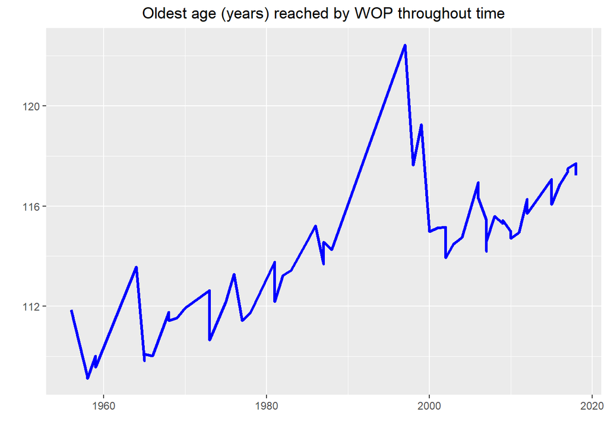

```r
ggplot(oldest_clean,
       aes(Death_Year, Age_Total)) +
       geom_line(color="blue", size=1.2) +
       labs(
         title = "Oldest age (years) reached by WOP throughout time",
         x = '',
         y = '') +
       theme(plot.title = element_text(hjust = 0.5))
```

Behind the variation, we can definitely see an upward trend here, possibly related to the rise in life expectancy through time. There is a peak above 122 years (!), related to Jeanne Calment (1875–1997), oldest person to have ever lived (whose age was independently verified), according to the Guiness Book.